# HW4. T-tests and ANOVA

Linguistic data: Quantitative analysis and vizualization

## Universal linguistic hierarchies: a case of Modern Greek (Standard and Cypriot dialects)

Data ([responces](https://raw.githubusercontent.com/LingData2019/LingData2020/master/data/greek-word-order-mono-acceptability-coded-rt.txt), [quesionnaire](https://raw.githubusercontent.com/LingData2019/LingData2020/master/data/greek-word-order-mono_socio.txt)) adapted from the survey: Leivada, Evelina; Westergaard, Marit, 2019, [Universal linguistic hierarchies are not innately wired](https://www.ncbi.nlm.nih.gov/pmc/articles/PMC6679903/#fn-1). PeerJ, v.7.

Source of data: TROLLing repository: Leivada, Evelina; Westergaard, Marit, 2019, “Replication Data for: Universal linguistic hierarchies are not innately wired”, https://doi.org/10.18710/NTLLUF, DataverseNO, V1

#### Constructions with two adjectives

In English, the order of two adjectives in phrases like:

```
 a big black bag # ok
*a black big bag # unacceptable, ungrammatically ill-formed, or semantically anomalous
```

is powered by the semantic class of adjective (e.g. the `color` adjective closer to the noun than the `size` adjective).

A syntactic hierarchy of closeness to the noun in Chomsky’s Universal Grammar suggests the following order and is claimed to be innate and universal (= valid for all languages).

```
Subjective Comment > Evidential > Size > Length
> Height > Speed > Depth > Width > Temperature > Wetness > Age
> Shape > Color > Nationality/Origin > Material
# (adapted from Scott, 2002: 114)
```

The goal of Leivada & Westergaard research is identify what happens when people process orderings that either comply with the hierrarchy or violate it.

#### Method

In the first experiment, 140 neurotypical, adult speakers completed a timed forced choice task that featured stimuli showing a combination of two adjectives and a concrete noun (e.g., *I bought a square black table*). Two types of responses were collected:

1. acceptability judgments on a 3-point Likert scale that featured the options
   1. wrong,
   2. neither correct nor wrong,
   3. correct;
2. reaction times (RT).

The task featured three conditions: 1. size adjective > nationality adjective, 2. color adjective > shape adjective, 3. subjective comment adjective > material adjective. Each condition had two orders. In the congruent order, the adjective pair was ordered in agreement with what is traditionally accepted as dictated by the universal hierarchy. In the incongruent order, the ordering was reversed, thus the hierarchy was violated.

In the second experiment, 30 bidialectals (native speakers of Standard and Cypriot Greek) were tested in both language varieties, 36 observations per participant, 18 for each variety.

Two kinds of [fillers](https://www.hlp.rochester.edu/resources/BCS152-Tutorial/Fillers.html) were used in both experiments, FillerAcceptable and FillerUnacceptable – sentences that included well-formed and ungrammatical structures, respectively. In both tasks the ratio of fillers to actual test structures was 2:1.

#### Data

```r
library(tidyverse)
mono_socio <- read_csv2("https://raw.githubusercontent.com/LingData2019/LingData2020/master/data/greek-word-order-mono_socio.txt")
```

```
## Using ',' as decimal and '.' as grouping mark. Use read_delim() for more control.
```

```r
mono <- read_csv2("https://raw.githubusercontent.com/LingData2019/LingData2020/master/data/greek-word-order-mono-acceptability-coded-rt.txt")
```

```
## Using ',' as decimal and '.' as grouping mark. Use read_delim() for more control.
```

see also [reading key for the data](https://www.ncbi.nlm.nih.gov/pmc/articles/PMC6679903/bin/peerj-07-7438-s001.txt)

```r
mono_socio
```

```
## # A tibble: 180 x 4
##    ParticipantID                  TypeOfQuestion QuestionCategory Responce
##    <chr>                          <chr>          <chr>            <chr>
##  1 2bc93481d25426f259a0f1a3d5d3e… Form           age              58
##  2 2bc93481d25426f259a0f1a3d5d3e… Form           country1         Nicosia
##  3 2bc93481d25426f259a0f1a3d5d3e… Form           country2         Kaimakli,Nico…
##  4 2bc93481d25426f259a0f1a3d5d3e… Form           education        College
##  5 2bc93481d25426f259a0f1a3d5d3e… Form           handedness       right
##  6 2bc93481d25426f259a0f1a3d5d3e… Form           sex              female
##  7 4b4c9debd4aedeb1fd3dfc9f1cab3… Form           age              24
##  8 4b4c9debd4aedeb1fd3dfc9f1cab3… Form           country1         Nicosia
##  9 4b4c9debd4aedeb1fd3dfc9f1cab3… Form           country2         Nicosia
## 10 4b4c9debd4aedeb1fd3dfc9f1cab3… Form           education        UniversityDeg…
## # … with 170 more rows
```

## 1. Data overview

### 1.1

Use `mono_socio` dataframe to answer the following questions:

1. How many participants are mentioned in this dataframe?
2. How many of them are males and females?
3. Which education levels are mentioned in the dataframe?
4. How many participants of each education levels are present?
5. How many left- and right-randed participants are present?

The following functions from tidyverse can be usefult for this problem: `filter`, `group_by`, `count` and `distinct`. (Another approach is to use `pivot_wider`.)

```r
mono_socio %>% distinct(ParticipantID) %>% count()
```

```
## # A tibble: 1 x 1
##       n
##   <int>
## 1    30
```

```r
mono_socio %>% filter(QuestionCategory == 'sex') %>% group_by(Responce) %>% count(Responce)
```

```
## # A tibble: 2 x 2
## # Groups:   Responce [2]
##   Responce     n
##   <chr>    <int>
## 1 female      19
## 2 male        11
```

```r
mono_socio %>% filter(QuestionCategory == 'education') %>% distinct(Responce)
```

```
## # A tibble: 4 x 1
##   Responce
##   <chr>
## 1 College
## 2 UniversityDegree
## 3 Postgraduate
## 4 PhDongoing
```

```r
mono_socio %>% filter(QuestionCategory == 'education') %>% count(Responce)
```

```
## # A tibble: 4 x 2
##   Responce             n
##   <chr>            <int>
## 1 College              3
## 2 PhDongoing           1
## 3 Postgraduate        14
## 4 UniversityDegree    12
```

```r
mono_socio %>% filter(QuestionCategory == 'handedness') %>% count(Responce)
```

```
## # A tibble: 2 x 2
##   Responce     n
##   <chr>    <int>
## 1 left         2
## 2 right       28
```

Compare you overview with that reported in Table 1 of the article. Sometimes replication data provided by authors does not allow on to reproduce their results. Let’s look at another dataframe, `mono`, that contains results of experiment 1.

```r
mono
```

```
## # A tibble: 7,560 x 6
##    ParticipantID  TypeOfQuestion  TypeOfStimuli WordOrder ResponseAccepta…    RT
##    <chr>          <chr>           <chr>         <chr>     <chr>            <dbl>
##  1 00e0b159cf5b9… AcceptabilityJ… Size-Nationa… Congruent Correct           1591
##  2 00e0b159cf5b9… AcceptabilityJ… Size-Nationa… Incongru… Correct           5504
##  3 00e0b159cf5b9… AcceptabilityJ… Size-Nationa… Congruent Correct           1333
##  4 00e0b159cf5b9… AcceptabilityJ… Size-Nationa… Incongru… Correct           1543
##  5 00e0b159cf5b9… AcceptabilityJ… Size-Nationa… Congruent Correct           1815
##  6 00e0b159cf5b9… AcceptabilityJ… Size-Nationa… Incongru… Correct           3059
##  7 00e0b159cf5b9… AcceptabilityJ… Shape-Color   Congruent Correct           1700
##  8 00e0b159cf5b9… AcceptabilityJ… Shape-Color   Incongru… Correct           2745
##  9 00e0b159cf5b9… AcceptabilityJ… Shape-Color   Congruent Correct           3237
## 10 00e0b159cf5b9… AcceptabilityJ… Shape-Color   Incongru… Correct           2911
## # … with 7,550 more rows
```

### 1.2

Create a plot that shows the RT distribution in experiment 1 (all participants and conditions taken together). What kind of plot would you choose? Use ggplot() for this problem.

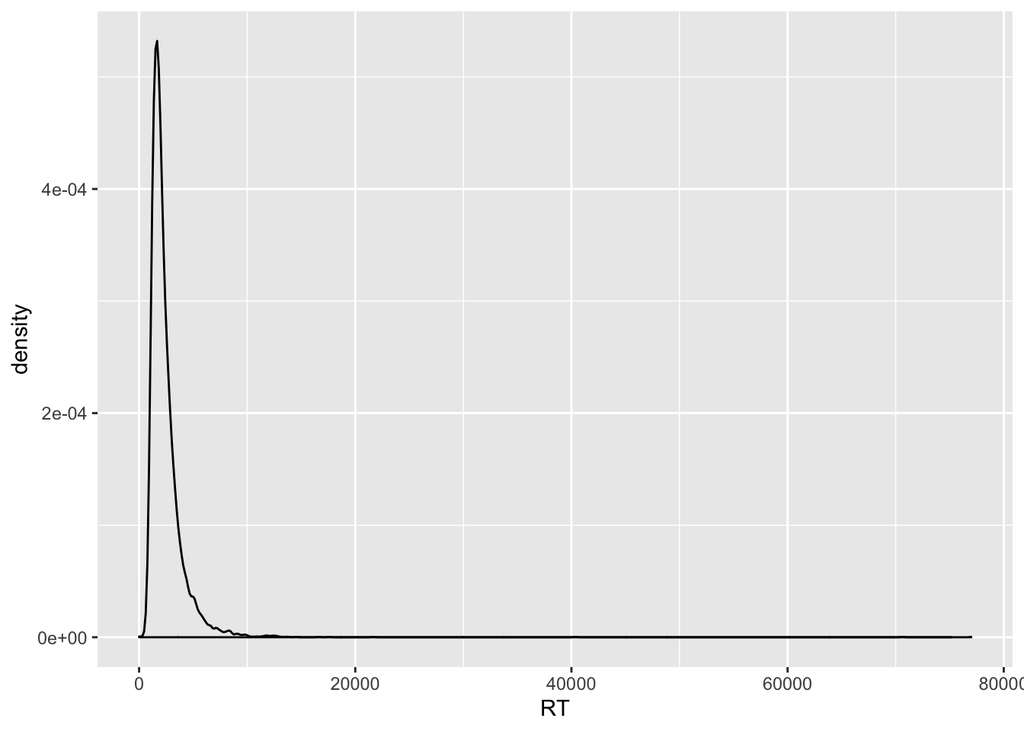

```r
library(ggplot2)
p <- ggplot(mono, aes(x=RT)) + geom_density()
p
```

Can we say that RT approximately follows normal distribution? Which features of RT distribution contradicts this assumption? (E.g. long left tail, long right tail, outliers, skewness, etc.). Answer: no, RT has a long right tail, while on the left it is limited by 0.

### 1.3

Normalise data applying the logarithm with base 10 (RTlog = log10(RT)). Use `mutate`.

```r
mono <- mutate(mono, RT_log = log10(RT))
```

### 1.4

Create a density plot that shows the RTlog distribution.

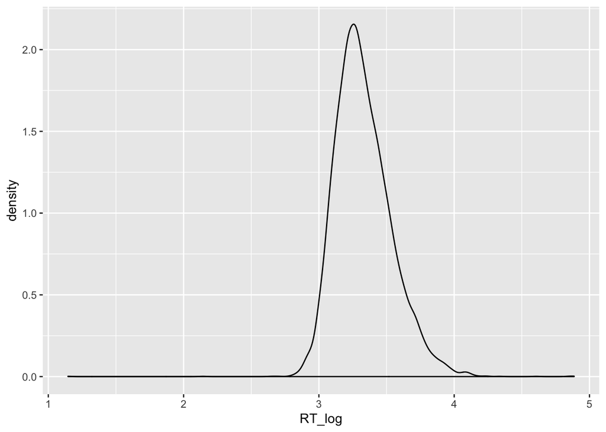

```r
ggplot(mono, aes(x=RT_log)) + geom_density()
```

Can we say that RTlog approximately follows normal distribution? What features of RTlog distribution contradicts this assumption? (E.g. long left tail, long right tail, outliers, skewness, etc.) Answer: RTlog is a little skewed towards the right, but overall it does approximately follow normal distribution.

### 1.5

Give a summary of `RTlog` distribution (min, max, mean, median, standard deviation)

```r
# hint: sd()
min(mono$RT_log)
```

```
## [1] 1.146128
```

```r
max(mono$RT_log)
```

```
## [1] 4.886446
```

```r
mean(mono$RT_log)
```

```
## [1] 3.328846
```

```r
median(mono$RT_log)
```

```
## [1] 3.301573
```

```r
sd(mono$RT_log)
```

```
## [1] 0.2076783
```

### 1.6

Filter out outliers. Remove from the table the following observations: * responses whose RT is below 600 ms (i.e., when a button is pressed too fast, without allowing enough time for actual consideration of the presented stimuli)  
* responses whose RTlog deviates from the mean value of RTlog for more than 3 standard deviations  
* fillers (both acceptable and unacceptable)  
Convert relevant variables to factors and save fitered data as `mono1`.

```r
mean_rtlog <- mean(mono$RT_log)
sd_rtlog <- sd(mono$RT_log)
mono1 <- mono %>%
  filter(TypeOfStimuli != 'FillerAcceptable' & TypeOfStimuli != 'FillerUnacceptable') %>%
  filter(RT >= 600 & RT_log <= mean_rtlog + 3*sd_rtlog & RT_log >= mean_rtlog - 3*sd_rtlog) %>%
  select(ParticipantID, TypeOfStimuli, WordOrder, AcceptabilityJ = ResponseAcceptabilityJudgement, RT_log) %>%
  mutate(ParticipantID = as.factor(ParticipantID),
         TypeOfStimuli = as.factor(TypeOfStimuli),
         WordOrder = as.factor(WordOrder),
         AcceptabilityJ = as.factor(AcceptabilityJ))
```

### 1.7

Calculate the number of observations in `mono1`.

```r
count(mono1)
```

```
## # A tibble: 1 x 1
##       n
##   <int>
## 1  2488
```

### 1.8

Reproduce Figure 1 from the article using `ggplot`.

Hint: You can make a summary and use `geom_col()` (see example [here](https://r-graphics.org/recipe-colors-mapping)). Use either facet_wrap or facet_grid to make six plots. Note that we figures created in 1.8-1.0 may look different from what plotted in the article.

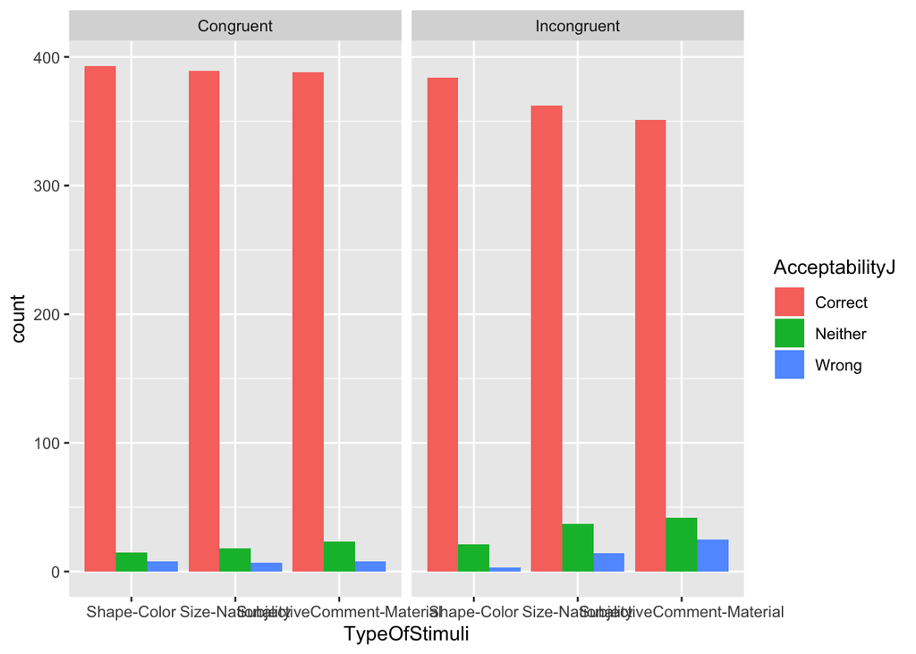

```r
ggplot(mono1, aes(x=TypeOfStimuli, fill=AcceptabilityJ)) + geom_bar(position='dodge') + facet_wrap(vars(WordOrder))
```

### 1.9

Reproduce Figure 2 from the article using ggplot.

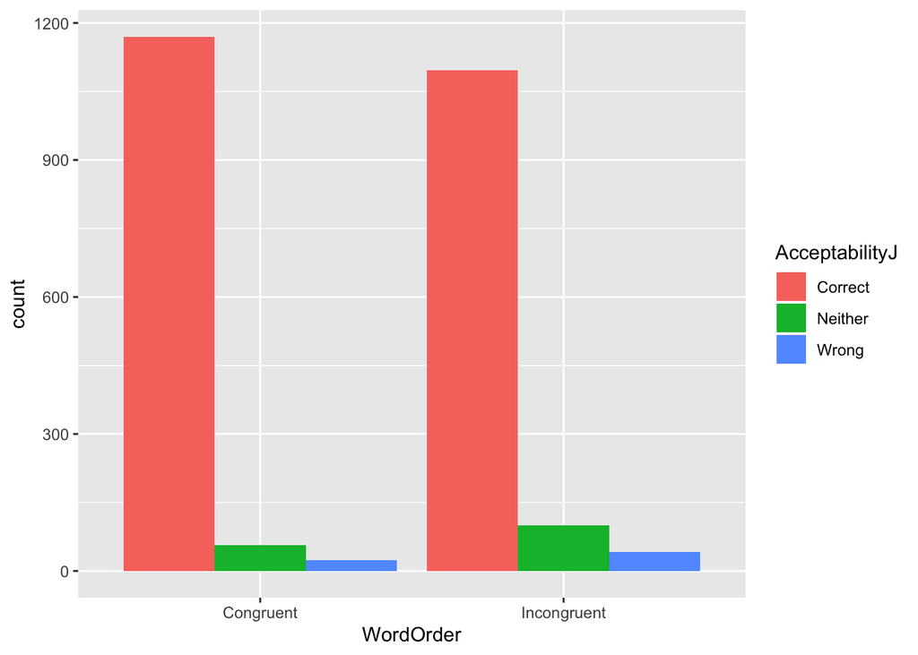

```r
ggplot(mono1, aes(x=WordOrder, fill=AcceptabilityJ)) + geom_bar(position='dodge')
```

### 1.10

Reproduce Figure 7 from the article using ggplot.

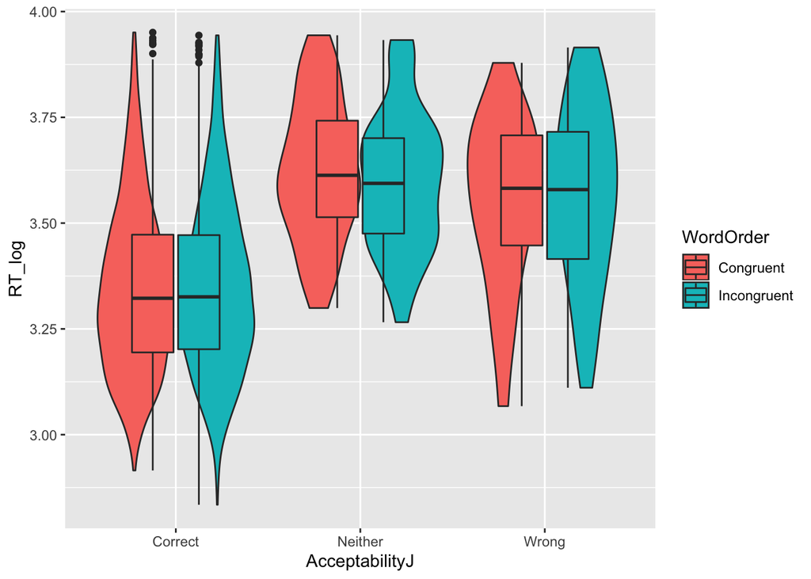

```r
ggplot(mono1, aes(x=AcceptabilityJ, y=RT_log, fill=WordOrder)) + geom_violin() + geom_boxplot(width=0.5)
```

### 1.11

For the same data, draw a lineplot for group means and standard errors using `ggline()`:

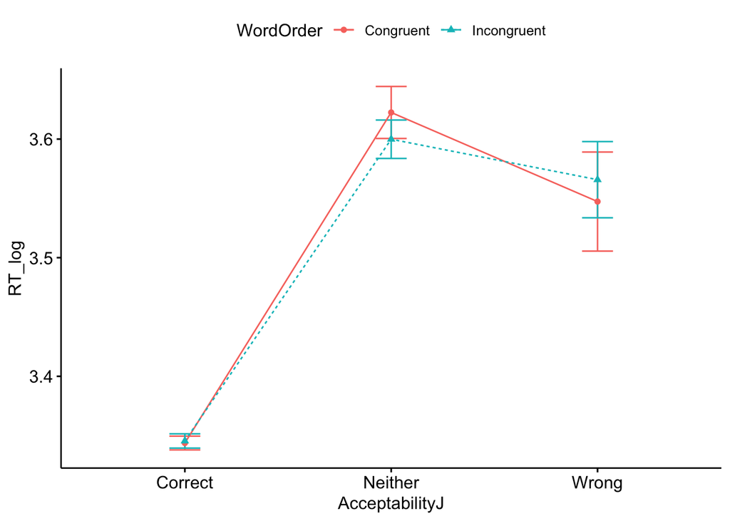

```r
library(ggpubr)
ggline(mono1, x='AcceptabilityJ', y='RT_log', color='WordOrder', linetype='WordOrder', shape='WordOrder', add='mean_se')
```

## 2. Difference in reaction time

Let us test are there any difference in the reaction time between congruent and incongruent orders. Reaction time is a numeric variable so we can use t-test to compare means. One option is to use two-sample t-test. However, as we have data for congruent and incongruent orders for *the same participants*, it is better to use *paired t-test* here. In paired t-test, for each participant, we will find difference of their reaction time in congruent and incongruent orders, and compare these differences with 0 using 1-sample t-test. To make sure that our data satisfy assumptions of t-test (values that we compare are independent samples from some approximately normal distributions), we will find mean logarithm of reaction time for each participant (across ovservations in all conditions), and consider them as our new sample.

### 2.1 Summarising

Use `group_by` and `summarise` to find mean logarithm of reaction time for each participant and each word order. Put this dataframe to `mean_rtlog_long` variable. It should be like

```
# A tibble: 280 x 3
   ParticipantID                    WordOrder   RTlog
   <fct>                            <fct>       <dbl>
 1 00e0b159cf5b9abcc73b92506d8b1c38 Congruent    3.24
 2 00e0b159cf5b9abcc73b92506d8b1c38 Incongruent  3.47
 3 021a49cde484f8fa18439f026ec99459 Congruent    3.22
 4 021a49cde484f8fa18439f026ec99459 Incongruent  3.21
 ...
```

```r
mean_rtlog_long <- mono1 %>%
  group_by(ParticipantID, WordOrder) %>%
  summarise(mean=mean(RT_log))

mean_rtlog_long
```

```
## # A tibble: 280 x 3
## # Groups:   ParticipantID [140]
##    ParticipantID                    WordOrder    mean
##    <fct>                            <fct>       <dbl>
##  1 00e0b159cf5b9abcc73b92506d8b1c38 Congruent    3.24
##  2 00e0b159cf5b9abcc73b92506d8b1c38 Incongruent  3.47
##  3 021a49cde484f8fa18439f026ec99459 Congruent    3.22
##  4 021a49cde484f8fa18439f026ec99459 Incongruent  3.21
##  5 02810ff2a65eae2b3e54ac57d906309d Congruent    3.46
##  6 02810ff2a65eae2b3e54ac57d906309d Incongruent  3.36
##  7 037c50e80288a89b13f4c77e0b825789 Congruent    3.55
##  8 037c50e80288a89b13f4c77e0b825789 Incongruent  3.55
##  9 054635a48143f6d4dd711cbb00b9f6fd Congruent    3.22
## 10 054635a48143f6d4dd711cbb00b9f6fd Incongruent  3.18
## # … with 270 more rows
```

### 2.2. Pivoting

Use `pivot_wider` to spread values of `RTlog` in `mean_rtlog_long` into two columns: `Congruent` and `Incongruent`. Put new dataframe in variable `mean_rtlog`. It should look like

```
# A tibble: 140 x 3
   ParticipantID                    Congruent Incongruent
   <fct>                                <dbl>       <dbl>
 1 00e0b159cf5b9abcc73b92506d8b1c38      3.24        3.47
 2 021a49cde484f8fa18439f026ec99459      3.22        3.21
 3 02810ff2a65eae2b3e54ac57d906309d      3.46        3.36
```

```r
mean_rtlog <- mean_rtlog_long %>% pivot_wider(names_from = WordOrder, values_from = mean)
mean_rtlog
```

```
## # A tibble: 140 x 3
## # Groups:   ParticipantID [140]
##    ParticipantID                    Congruent Incongruent
##    <fct>                                <dbl>       <dbl>
##  1 00e0b159cf5b9abcc73b92506d8b1c38      3.24        3.47
##  2 021a49cde484f8fa18439f026ec99459      3.22        3.21
##  3 02810ff2a65eae2b3e54ac57d906309d      3.46        3.36
##  4 037c50e80288a89b13f4c77e0b825789      3.55        3.55
##  5 054635a48143f6d4dd711cbb00b9f6fd      3.22        3.18
##  6 066f8885734d3b91f905df8c23195a27      3.39        3.38
##  7 086805c265966ff2a53482f3b6c1328c      3.37        3.42
##  8 0912f84f2fb81492f8e7a4c5c02d33a9      3.18        3.21
##  9 09b1c9e98227331746533f60cc9b2c2d      3.33        3.43
## 10 0a14b7b4f101746c9cd29fbaa746ba5e      3.48        3.45
## # … with 130 more rows
```

### 2.3. Two-sample t-test

Let us try to apply two-sample t-test to our data. Consider values in columns `Congruent` and `Incongruent` as two independent samples. Our null hypothesis is that these two samples are from populations with equal means. Alternative hypothesis: population mean for incongruate word order is larger (people need more time to ’parse’ it). Use `t.test` function to perform a test. Don’t forget to specify `alternative`.

```r
t.test(mean_rtlog$Congruent, mean_rtlog$Incongruent, alternative = 'less')
```

```
##
##  Welch Two Sample t-test
##
## data:  mean_rtlog$Congruent and mean_rtlog$Incongruent
## t = -0.90314, df = 277.26, p-value = 0.1836
## alternative hypothesis: true difference in means is less than 0
## 95 percent confidence interval:
##        -Inf 0.01313405
## sample estimates:
## mean of x mean of y
##  3.361292  3.377166
```

Would you reject null hypothesis (under 5% significance level) according to this test? Answer: no.

What claim about logarithms of reaction time for Congruent and Incongruent stimuli can you make according to this test? Answer: the difference in their means is not statistically significant.

### 2.4. Paired t-test: manually

To use paired t-test, let us find difference between logarithms of reaction time for each participant. Use `mutate` and add variable `diff` with aforementioned meaning to dataframe `mean_rtlog`. Save result as `mean_rtlog` again. Then compare mean of `diff` with 0 using 1-sample t-test. (Use appropriate alternative.)

```r
mean_rtlog <- mutate(mean_rtlog, diff = Incongruent - Congruent)
t.test(mean_rtlog$diff, alternative = 'greater')
```

```
##
##  One Sample t-test
##
## data:  mean_rtlog$diff
## t = 2.3235, df = 139, p-value = 0.0108
## alternative hypothesis: true mean is greater than 0
## 95 percent confidence interval:
##  0.004561374         Inf
## sample estimates:
##  mean of x
## 0.01587439
```

Whould you reject null hypothesis? Answer: tes.

What claim about logarithms of reaction time for Congruent and Incongruent stimuli can you make now? Answer: actually, the mean logarithm of reaction time for Incongruent stimuli is larger than that for Congruent stimuli.

How can you interpret difference with the result of 2.3? Answer: using a standard two-sample t-test leads to averaging reaction times across subjects which smooths out the differences. Using a paired test allows us to use the information about changes in individual subjects’ reaction times.

#### 2.5. Paired t-test out of the box

In fact, we can avoid manual calculation of difference and perform paired t-test using `t.test` function with parameter `paired = True`. Apply this function to your data and make sure you get the same result as in 2.4.

```r
t.test(mean_rtlog$Congruent, mean_rtlog$Incongruent, alternative = 'less', paired = TRUE)
```

```
##
##  Paired t-test
##
## data:  mean_rtlog$Congruent and mean_rtlog$Incongruent
## t = -2.3235, df = 139, p-value = 0.0108
## alternative hypothesis: true difference in means is less than 0
## 95 percent confidence interval:
##          -Inf -0.004561374
## sample estimates:
## mean of the differences
##             -0.01587439
```

## 3. Difference between conditions

Now we will consider reaction time for Incongruent word ordering only. Let us check are there any statistically significant difference in logarithm of reaction time for different conditions (types of stimuli).

### 3.1 Data preparation

Filter only observation with `Incongruent` word order, then find average logarithm of reaction time for each participant and each type of stimuli. Save new dataframe as `incong_rtlog` variable. It should look like the following table:

[output not shown]

```r
incong_rtlog <- mono1 %>%
  filter(WordOrder == 'Incongruent') %>%
  group_by(ParticipantID, TypeOfStimuli) %>%
  summarise(mean=mean(RT_log))

incong_rtlog
```

```
## # A tibble: 420 x 3
## # Groups:   ParticipantID [140]
##    ParticipantID                    TypeOfStimuli               mean
##    <fct>                            <fct>                      <dbl>
##  1 00e0b159cf5b9abcc73b92506d8b1c38 Shape-Color                 3.49
##  2 00e0b159cf5b9abcc73b92506d8b1c38 Size-Nationality            3.47
##  3 00e0b159cf5b9abcc73b92506d8b1c38 SubjectiveComment-Material  3.44
##  4 021a49cde484f8fa18439f026ec99459 Shape-Color                 3.20
##  5 021a49cde484f8fa18439f026ec99459 Size-Nationality            3.23
##  6 021a49cde484f8fa18439f026ec99459 SubjectiveComment-Material  3.21
##  7 02810ff2a65eae2b3e54ac57d906309d Shape-Color                 3.48
##  8 02810ff2a65eae2b3e54ac57d906309d Size-Nationality            3.31
##  9 02810ff2a65eae2b3e54ac57d906309d SubjectiveComment-Material  3.29
## 10 037c50e80288a89b13f4c77e0b825789 Shape-Color                 3.67
## # … with 410 more rows
```

### 3.2 Statistical testing

Use appropriate statistical test to answer the following question: are there any statistically significant difference in logarithm of reaction time for different conditions (types of stimuli)? Choose the test and provide justification for your choice. Provide your code, results and interpretation. What is your answer to the question?

```r
res <- aov(mean ~ ParticipantID + TypeOfStimuli, data=incong_rtlog)
summary(res)
```

```
##                Df Sum Sq Mean Sq F value  Pr(>F)
## ParticipantID 139  9.520 0.06849   8.975 < 2e-16 ***
## TypeOfStimuli   2  0.247 0.12370  16.209 2.2e-07 ***
## Residuals     278  2.122 0.00763
## ---
## Signif. codes:  0 '***' 0.001 '**' 0.01 '*' 0.05 '.' 0.1 ' ' 1
```

Answer: we are going to use a two-way ANOVA test since it allows us to test whether and how two independent categorical variables affect the value of the dependent variable (mean). The results are as follows: for both factors, we observe a high F-value and a very low p-value. Thus we are to reject the null hypothesis that the expected values are equal across different values of the independent variables.

### 3.3 Post-hoc analysis: which differences are significant?

If we compare means for several (more than two) groups and reject null hypothesis that corresponding population means are equal to each other, the next natural question is to find all pairs of groups which difference is statistically significant. As we discussed at the lecture, pairwise t-tests cannot be used here without appropriate corrections. Instead, one can use Tukey Honest Significant Differences. It reports adjusted confidence intervals for differences between group means for each pair of groups as well as p-values for null hypothesis ’difference is equal to zero’.

Apply `TukeyHSD` to the result of 3.2 and report which pair of conditions has statistically significant difference between logarithms of reaction time.

```r
TukeyHSD(res, 'TypeOfStimuli')
```

```
##   Tukey multiple comparisons of means
##     95% family-wise confidence level
##
## Fit: aov(formula = mean ~ ParticipantID + TypeOfStimuli, data = incong_rtlog)
##
## $TypeOfStimuli
##                                                     diff         lwr
## Size-Nationality-Shape-Color                -0.009997979 -0.03460109
## SubjectiveComment-Material-Shape-Color      -0.055750104 -0.08035321
## SubjectiveComment-Material-Size-Nationality -0.045752126 -0.07035524
##                                                     upr     p adj
## Size-Nationality-Shape-Color                 0.01460513 0.6043360
## SubjectiveComment-Material-Shape-Color      -0.03114699 0.0000006
## SubjectiveComment-Material-Size-Nationality -0.02114902 0.0000495
```

Answer: SubjectiveComment-Material and Shape-Color, SubjectiveComment-Material and Size-Nationality have statistically significant differences.

### R code cookbook

**Violin plot** – is similar to box plots, except that they also show the approximation of probability density of the data at different values. Typically, violin plots will include a marker for the median of the data and a box indicating the interquartile range, as in standard box plots.

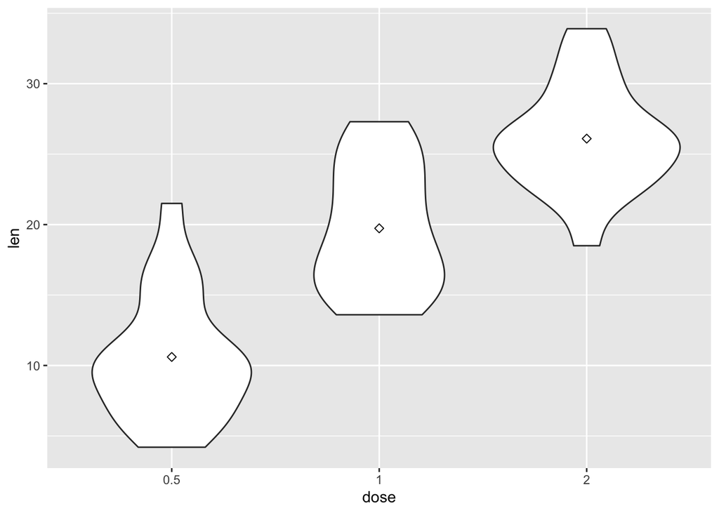

```r
ToothGrowth$dose <- as.factor(ToothGrowth$dose)
p <- ggplot(ToothGrowth, aes(x=dose, y=len)) +
  geom_violin()
p + stat_summary(fun.y=mean, geom="point", shape=23, size=2)
```

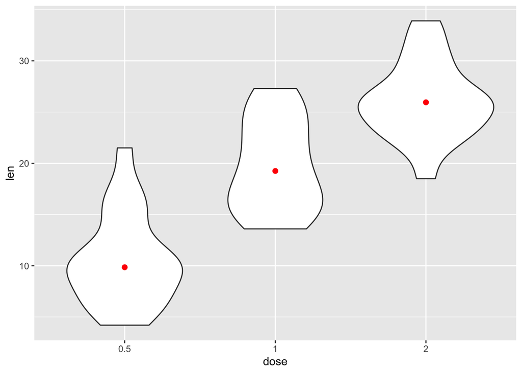

```r
p + stat_summary(fun.y=median, geom="point", size=2, color="red")
```

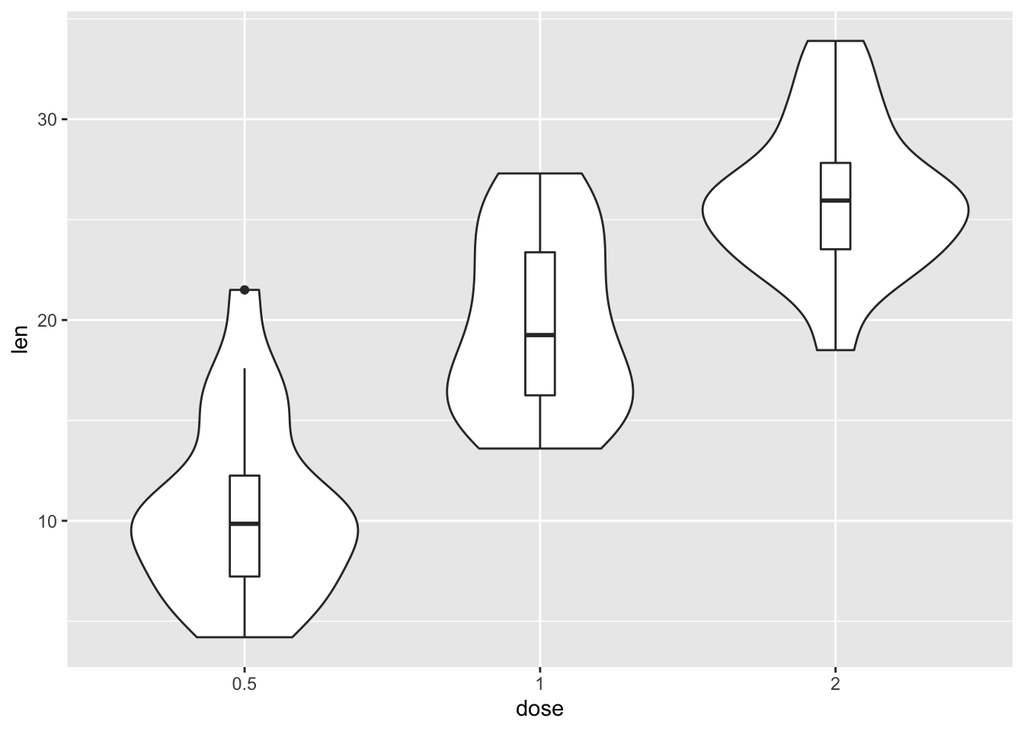

```r
p + geom_boxplot(width=0.1)
```

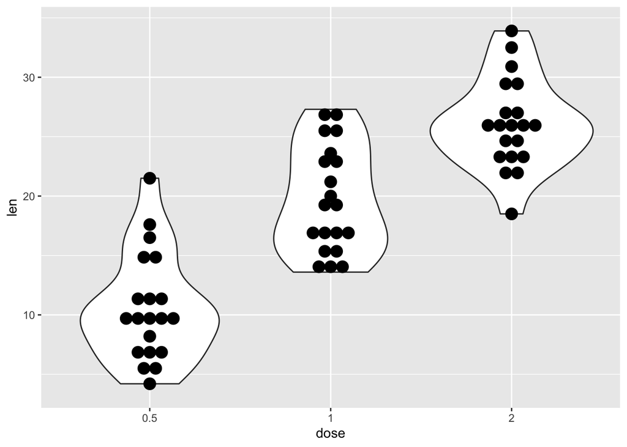

```r
# violin plot with dot plot
p + geom_dotplot(binaxis='y', stackdir='center', dotsize=1)
```

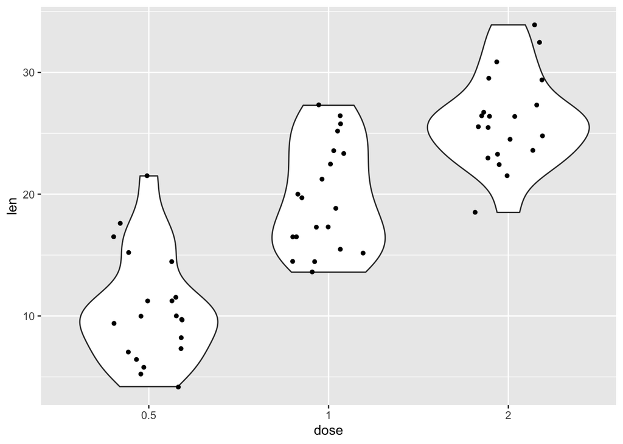

```r
# violin plot with jittered points
# 0.2 : degree of jitter in x direction
p + geom_jitter(shape=16, position=position_jitter(0.2))
```

**Line plot** You can create a line plot of mean +/- error using the function ggline()[in ggpubr]. Basic line plots of means +/- se with jittered points:

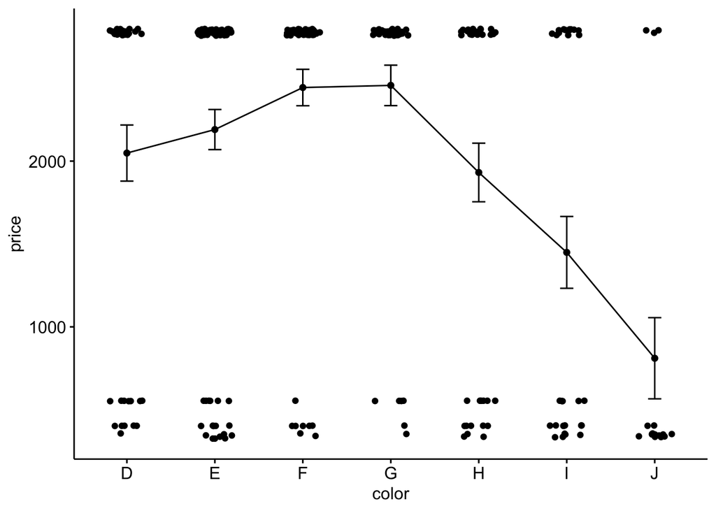

```r
library(ggpubr)
ggline(diamonds[1:300,], x = "color", y = "price",
       add = c("mean_se", "jitter"))
```

Split and color by group:

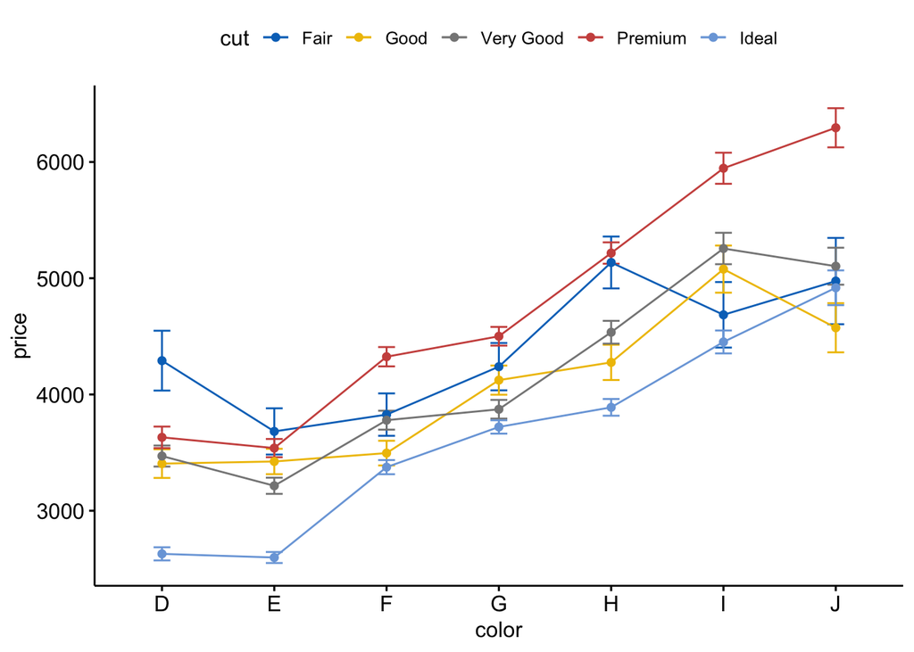

```r
ggline(diamonds, x = "color", y = "price",
       add = "mean_se",
       color = "cut", palette = "jco")
```

```r
diamonds
```

```
## # A tibble: 53,940 x 10
##    carat cut       color clarity depth table price     x     y     z
##    <dbl> <ord>     <ord> <ord>   <dbl> <dbl> <int> <dbl> <dbl> <dbl>
##  1 0.23  Ideal     E     SI2      61.5    55   326  3.95  3.98  2.43
##  2 0.21  Premium   E     SI1      59.8    61   326  3.89  3.84  2.31
##  3 0.23  Good      E     VS1      56.9    65   327  4.05  4.07  2.31
##  4 0.290 Premium   I     VS2      62.4    58   334  4.2   4.23  2.63
##  5 0.31  Good      J     SI2      63.3    58   335  4.34  4.35  2.75
##  6 0.24  Very Good J     VVS2     62.8    57   336  3.94  3.96  2.48
##  7 0.24  Very Good I     VVS1     62.3    57   336  3.95  3.98  2.47
##  8 0.26  Very Good H     SI1      61.9    55   337  4.07  4.11  2.53
##  9 0.22  Fair      E     VS2      65.1    61   337  3.87  3.78  2.49
## 10 0.23  Very Good H     VS1      59.4    61   338  4     4.05  2.39
## # … with 53,930 more rows
```

**Using fill_palette**

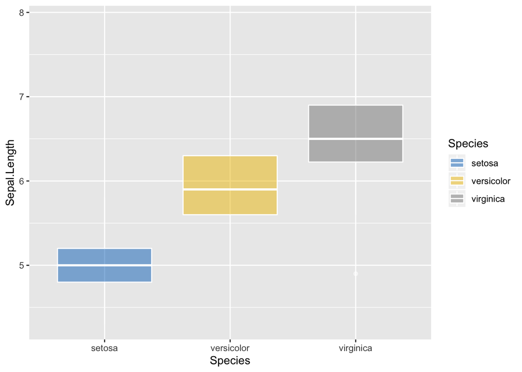

```r
ggplot(iris, aes(Species, Sepal.Length))+
  geom_boxplot(aes(fill = Species), color = "white", alpha = 0.5)+
  fill_palette("jco")
```

See more examples of ggpubr plots: [here](https://rpkgs.datanovia.com/ggpubr/index.html).